# Simulations Causal Forests

## Simulations Causal Forests

#Variables smsa66 lived in smsa in 1966 ?

smsa76 lived in smsa in 1976 ?

age76 age in 1976

daded dads education (imputed avg if missing)

south66 lived in south in 1966 ?

south76 lived in south in 1976 ?

lwage76 log wage in 1976 (outliers trimmed)

famed mom-dad education class (1-9)

black black ?

wage76 wage in 1976 (raw, cents per hour)

enroll76 enrolled in 1976 ?

kww the kww score

iqscore a normed IQ score

mar76 married in 1976 ?

libcrd14 library card in home at age 14 ?

exp76 experience in 1976

```r
Schooling$high <- 1*(Schooling$wage76 > quantile(Schooling$wage76,0.8))
### train/test sample
set.seed(1789)
ind <- sample(2, nrow(Schooling), replace=TRUE,prob=c(0.7,0.3))
trainData <- Schooling[ind==1,]
testData <-Schooling[ind==2, ]

formula1 <- wage76~  iqscore + black + exp76+ age76
Tree1 <- ctree(formula1, trainData    )
Tree1 <- tree(formula1, trainData    )
summary(Tree1)
```

```
##
## Regression tree:
## tree(formula = formula1, data = trainData)
## Number of terminal nodes:  7
## Residual mean deviance:  59100 = 85750000 / 1451
## Distribution of residuals:
##    Min. 1st Qu.  Median    Mean 3rd Qu.    Max.
## -642.90 -159.00  -33.55    0.00  121.70 1637.00
```

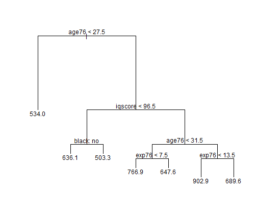

```r
plot(Tree1)
text(Tree1, pretty=0)
```

# crossvalidation error

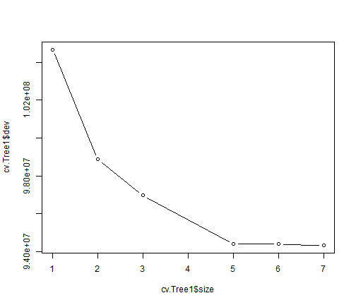

```r
cv.Tree1 <- cv.tree(Tree1)
## plot cross validation error cv.Tree1$dev as a function of size
plot(cv.Tree1$size,cv.Tree1$dev, type='b')
```

```r
prune.Tree1 <- prune.tree(Tree1, best=5)
```

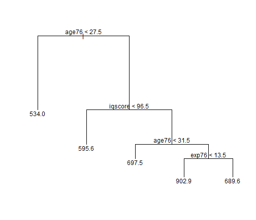

```r
plot(prune.Tree1)
text(prune.Tree1, pretty=0)
```

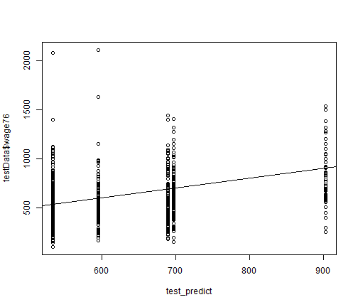

```r
test_predict <- predict(prune.Tree1, newdata= testData)
plot(test_predict, testData$wage76)
abline(0,1)
```

```r
mean((test_predict - testData$wage76)^2)
```

```
## [1] 59304.88
```

### Forests

```r
RF1 <- cforest(formula1, trainData, controls=cforest_control( mtry=4,mincriterion = 0)    )
test_predict <- predict(RF1 ,newdata = testData, type = "response")
```

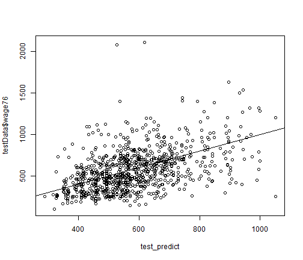

```r
plot(test_predict, testData$wage76)
abline(0,1)
```

```r
mean((test_predict - testData$wage76)^2)
```

```
## [1] 50505.29
```

```r
varimp(RF1 )
```

```
##   iqscore     black     exp76     age76
##  1462.498  4197.515 10680.731 36815.135
```

#### classification tree

```r
formula1 <- high~ iqscore + black + exp76+ age76
Tree1 <- ctree(formula1, trainData    )
# Tree1 <- tree(formula1, trainData    )
```

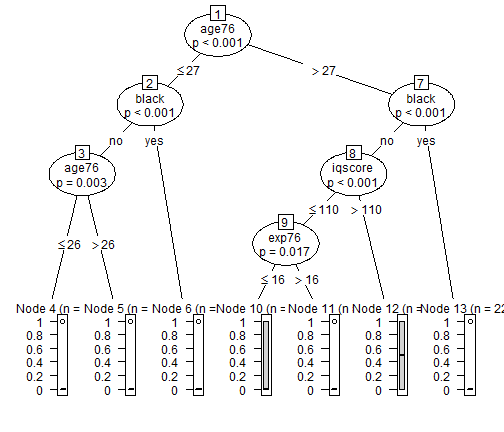

```r
# summary(Tree1)
plot(Tree1)
```

```r
# text(Tree1, pretty=0)
```

```r
train_predict <- predict(Tree1, trainData, type="response")
```

## in-sample confusion matrix

```r
table(train_predict>0.5,trainData$high)
```

```
##
##            0    1
##   FALSE 1699  428
```

```r
mean( (train_predict>0.5) != trainData$high )*100
```

```
## [1] 20.12224
```

```r
test_predict <- predict(Tree1, testData, type="response")
table(test_predict>0.5,testData$high)
```

```
##
##           0   1
##   FALSE 727 156
```

```r
mean( (test_predict>0.5) != testData$high )*100
```

```
## [1] 17.66704
```

## Causal Forest

Generate feature data: \( X \sim \mathcal{N}(0, I_{p\times p}) \)

```r
n = 2000; p = 10
X = matrix(rnorm(n*p), n, p)
out_len = 101
X.test = matrix(0, out_len , p)
X.test[,1] = seq(-2, 2, length.out = out_len )
```

Then we simulate the treatement variable, with propensity score \( p(X) = 0.5 \), and the outcome variable \[ Y = \tau(X) D + X_2 + X_3 \wedge 0 + \varepsilon, \quad \varepsilon \sim \mathcal{N}(0,1), \] \[ \tau(X) = X_1 \vee 0 \]

```r
# Perform treatment effect estimation.
D = rbinom(n, 1, 0.5)
Y = pmax(X[,1], 0) * D + X[,2] + pmin(X[,3], 0) + rnorm(n)
dataTrain <- as.data.frame(cbind(X,Y,D))

formula1 = paste( paste(colnames(dataTrain)[11], "~ "),paste(colnames(dataTrain)[1:10],collapse="+"))
# tau.forest = causalForest(formula1, data=as.matrix(dataTrain), treatment = dataTrain$D,
#                             split.Rule="CT", split.Honest=T,  split.Bucket=F, bucketNum = 5,
#                             bucketMax = 100, cv.option="CT", cv.Honest=T, minsize = 2L,
#                             split.alpha = 0.5, cv.alpha = 0.5,
#                             sample.size.total = floor(nrow(dataTrain) / 2), sample.size.train.frac = .5,
#                             mtry = ceiling(ncol(dataTrain)/3), nodesize = 3, num.trees= 5,ncolx=p,ncov_sample=p)


ind <- sample(1:n,floor(n/2),replace=F)
# honestTree <- honest.causalTree(formula1, data=dataTrain[ind ,], treatment = dataTrain$D[ind ],
#                                 est_data = dataTrain[-ind, ],
#                                 est_treatment =  dataTrain$D[-ind ],
#                                 split.Rule = "CT", split.Honest = T,
#                                 HonestSampleSize = nrow(dataTrain[-ind, ]),
#                                 split.Bucket = T, cv.option = "CT")
#
#  honestTree$cptable
```

```r
# opcp <-  honestTree$cptable[,1][which.min(honestTree$cptable[,4])]
# opTree <- prune(honestTree, opcp)
```

```r
# rpart.plot(opTree)
```

```r
# out <- matrix(0,1,out_len )
# #### Forest
# s=floor(0.7*n)
# ntree=300
#
# for(b in 1:ntree){
#   ind <- sample(1:n,s,replace=F)
#   dataTrain <- as.data.frame(cbind(X,Y,D))[ind,]
#   ind <- sample(1:s,floor(s/2),replace=F)
#   honestTree <- honest.causalTree(formula1, data=dataTrain[ind ,], treatment = dataTrain$D[ind ],
#                                   est_data = dataTrain[-ind, ],
#                                   est_treatment =  dataTrain$D[-ind ],
#                                   split.Rule = "CT", split.Honest = T,
#                                   HonestSampleSize = nrow(dataTrain[-ind, ]),
#                                   split.Bucket = T, cv.option = "CT")
#   opcp <-  honestTree$cptable[,1][which.min(honestTree$cptable[,4])]
#   opTree <- prune(honestTree, opcp)
# out <- out + predict(opTree, newdata=as.data.frame(X.test))
# }
# out <- out /ntree
```

```r
# plot(X.test[,1],out, ylim = range(out, 0, 2), xlab = "x", ylab = "tau", type = "l")
# lines(X.test[,1], pmax(0, X.test[,1]), col = 2, lty = 2)
```

```r
library(grf)
# cfpredtest <- predict(cf, newdata=dataTest, type="vector")
tau.forest_2 = causal_forest(X, Y, D, precompute.nuisance = FALSE)
tau.hat_2 = predict(tau.forest_2, X.test)

tau.forest = causal_forest(X, Y, D)
tau.hat = predict(tau.forest, X.test)
variable_importance(tau.forest)
```

```
##             [,1]
##  [1,] 0.70329348
##  [2,] 0.02798928
##  [3,] 0.02597512
##  [4,] 0.03096732
##  [5,] 0.02857355
##  [6,] 0.04540747
##  [7,] 0.04276017
##  [8,] 0.04374960
##  [9,] 0.02601756
## [10,] 0.02526645
```

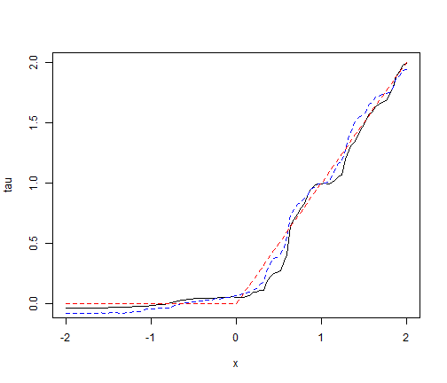

```r
plot(X.test[,1], tau.hat$predictions, ylim = range(tau.hat$predictions, 0, 2), xlab = "x", ylab = "tau", type = "l")
lines(X.test[,1], tau.hat_2$predictions, col = 4, lty = 2)
lines(X.test[,1], pmax(0, X.test[,1]), col = 2, lty = 2)
```

```r
# Estimate the conditional average treatment effect on the full sample (CATE).
estimate_average_effect(tau.forest, target.sample = "all")
```

```
## Error in estimate_average_effect(tau.forest, target.sample = "all"): impossible de trouver la fonction "estimate_average_effect"
```

```r
# Estimate the conditional average treatment effect on the treated sample (CATT).
# Here, we don't expect much difference between the CATE and the CATT, since
# treatment assignment was randomized.
estimate_average_effect(tau.forest, target.sample = "treated")
```

```
## Error in estimate_average_effect(tau.forest, target.sample = "treated"): impossible de trouver la fonction "estimate_average_effect"
```

```r
# Add confidence intervals for heterogeneous treatment effects
tau.forest = causal_forest(X, Y, D, num.trees = 4000)
tau.hat = predict(tau.forest, X.test, estimate.variance = TRUE)
sigma.hat = sqrt(tau.hat$variance.estimates)
```

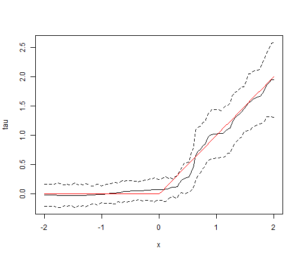

```r
plot(X.test[,1], tau.hat$predictions, ylim = range(tau.hat$predictions + 1.96 * sigma.hat, tau.hat$predictions - 1.96 * sigma.hat, 0, 2), xlab = "x", ylab = "tau", type = "l")
lines(X.test[,1], tau.hat$predictions + 1.96 * sigma.hat, col = 1, lty = 2)
lines(X.test[,1], tau.hat$predictions - 1.96 * sigma.hat, col = 1, lty = 2)
lines(X.test[,1], pmax(0, X.test[,1]), col = 2, lty = 1)
```

Add confidence intervals for heterogeneous treatment effects; growing more trees is now recommended.

```r
tau.forest = causal_forest(X, Y, D, num.trees = 4000)
tau.hat = predict(tau.forest, X.test, estimate.variance = TRUE)
sigma.hat = sqrt(tau.hat$variance.estimates)
```

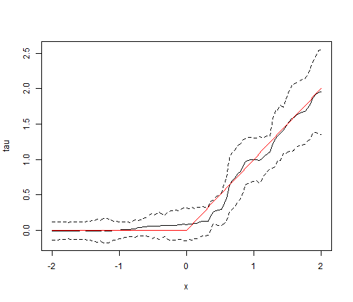

```r
plot(X.test[,1], tau.hat$predictions, ylim = range(tau.hat$predictions +
            1.96 * sigma.hat, tau.hat$predictions - 1.96 * sigma.hat, 0, 2),
     xlab = "x", ylab = "tau", type = "l")
lines(X.test[,1], tau.hat$predictions + 1.96 * sigma.hat, col = 1, lty = 2)
lines(X.test[,1], tau.hat$predictions - 1.96 * sigma.hat, col = 1, lty = 2)
lines(X.test[,1], pmax(0, X.test[,1]), col = 2, lty = 1)
```

```r
### Without confounding factors (p(x) =constant)

# Generate data.
n = 10000; p = 3
X = matrix(runif(n*p), n, p)
X.test =matrix(runif(n*p), n, p)
# Perform treatment effect estimation.
D = rbinom(n, 1, 0.5)
zeta1 <- function(x){
  return(1+ 1/(1+ exp(-20*(x-1/3))))
}
Y = (D-0.5)*(zeta1(X[,1]) *zeta1(X[,2])) + rnorm(n)
truth = (zeta1(X.test[,1]) *zeta1(X.test[,2]))

##### with CausalForest package
ntree=500
forest = causalForest(X, Y, D, num.trees = ntree, sample.size = n / 10)
```

```
## [1] "Building trees ..."
## [1] "Tree 1"
## [1] "Tree 2"
## [1] "Tree 3"
## [1] "Tree 4"
## [1] "Tree 5"
## [1] "Tree 6"
## [1] "Tree 7"
## [1] "Tree 8"
## [1] "Tree 9"
## [1] "Tree 10"
## [1] "Tree 11"
## [1] "Tree 12"
## [1] "Tree 13"
## [1] "Tree 14"
```

[output cut: 486 more lines]

```r
tauhat.rf <- predict(forest, X.test)
```

```r
# #### with the grf package
# tau.forest = causal_forest(X, Y, D, sample.fraction = 0.5,num.tree = 2000  )
# # tau.knn = iv.series(X, Y, W,Z=NULL  )
# tau.hat = predict(tau.forest, X.test)

# ##### kNN comparison
library(FNN)
# neighbors = get.knnx(X,X.test, k=100)$nn.index

kk = c(seq(3, 99, by = 3))
knn.mses = sapply(kk, function(k) {
  neighbors = get.knnx(X,X.test, k=k)$nn.index
  tauhat =  apply(neighbors, 1, function(nn) {
    Yp = Y[nn]
    Dp = D[nn]
    y.hat = mean(Yp[Dp==1]) -  mean(Yp[Dp==0])
  })
  mean((truth - tauhat)^2)
})

print(knn.mses)
```

```
##  [1]        NaN        NaN        NaN        NaN        NaN        NaN
##  [7] 0.20683755 0.17826340 0.15810849 0.14338918 0.13156713 0.12159858
## [13] 0.11304527 0.10603162 0.09910287 0.09304895 0.08753174 0.08385623
## [19] 0.07975805 0.07662838 0.07330064 0.07021351 0.06729220 0.06468396
## [25] 0.06243702 0.06042775 0.05878345 0.05716724 0.05552211 0.05395682
## [31] 0.05276476 0.05170495 0.05041966
```

Comparison with k-nearest neighbors: \[ \widehat{\tau}_{kNN} = \dfrac{1}{k}\sum_{i \in S_1(x)}Y_i - \dfrac{1}{k}\sum_{i \in S_0(x)}Y_i \]

```r
#### compute for the optimum
k.opt = kk[which.min(knn.mses)]
neighbors = get.knnx(X,X.test, k=k.opt)$nn.index
tau.hat.k <-  apply(neighbors, 1, function(nn) {
  Yp = Y[nn]
  Dp = D[nn]
  y.hat = mean(Yp[Dp==1]) -  mean(Yp[Dp==0])
})


library(RColorBrewer)
library(Hmisc)
library(mgcv)
```

```r
library(ggplot2)
x <- seq(-1, 1, length=100)
y <- seq(-1, 1, length=100)
xy <- expand.grid(x=x, y=y)
# xy <- cbind(xy , matrix(0,100,1))
xy <- cbind(xy , matrix(0,100,1), matrix(0,100,1), matrix(0,100,1), matrix(0,100,1))

k <- 10
my.cols <- rev(brewer.pal(k, "RdYlBu"))

minp = min(truth, tauhat.rf, tau.hat.k)
maxp = max(truth, tauhat.rf, tau.hat.k)
rngp = maxp - minp

ncol = 100

true.scl = pmax(ceiling(ncol * (truth - minp) / rngp), 1)
rf.scl = pmax(ceiling(ncol * (tauhat.rf - minp) / rngp), 1)
knn.scl = pmax(ceiling(ncol * (tau.hat.k - minp) / rngp), 1)
hc = heat.colors(ncol)
```

The True Treatment effect

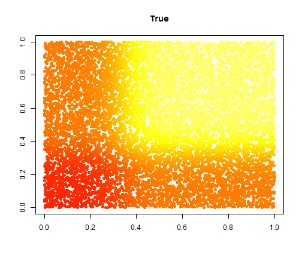

```r
plot(X.test[,1], X.test[,2], pch = 16, col = hc[true.scl], xlab = "", ylab = "",main = "True")
```

The treatment effect estimated via random forest

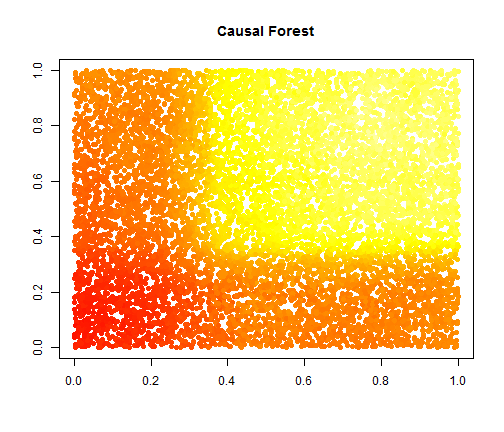

```r
plot(X.test[,1], X.test[,2], pch = 16, col = hc[rf.scl], xlab = "", ylab = "",main = "Causal Forest")
```

The treatment effect estimated via kNN

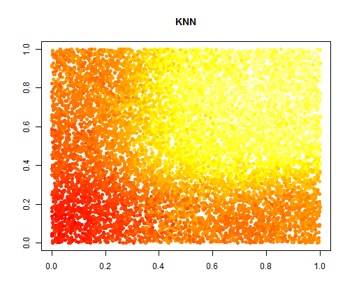

[output not shown]

[output not shown]

```r
plot(X.test[,1], X.test[,2], pch = 16, col = hc[knn.scl], xlab = "", ylab = "",main = "KNN")
```

```r
tau.hat.k <-  apply(neighbors, 1, function(nn) {
  Yp = Y[nn]
  Dp = D[nn]
  y.hat = mean(Yp[Dp==1]) -  mean(Yp[Dp==0])
})
# tau.hat = predict(tau.forest, xy)
colnames(xy) <- colnames(X.test)
tau.hat =predict(forest,xy)
z <- matrix(tau.hat, length(x), length(y))
z_k <- matrix(tau.hat.k, length(x), length(y))
z1 <- matrix(zeta1(xy[,1]) *zeta1(xy[,2]), length(x), length(y))

# z1_cut <-cut(tau.hat$predictions, quantile(tau.hat$predictions,seq(0,1, length.out=k))+seq(0,0.001, length.out=k)   )
```

The treatment effect estimated via random forests

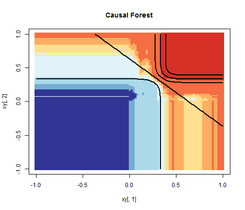

```r
z1_cut <-cut(tau.hat, quantile(tau.hat,seq(0,1, length.out=k))+seq(0,0.001, length.out=k)   )
plot(xy[,1],xy[,2], col=my.cols[z1_cut], pch = 15, main="Causal Forest")
contour(x,y,z1, drawlabels=FALSE, nlevels=k, lwd=2, add=TRUE)
```

The treatment effect estimated via kNN

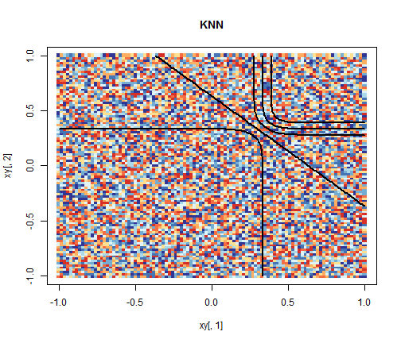

```r
z1_cut <-cut(tau.hat.k, quantile(tau.hat.k,seq(0,1, length.out=k))+seq(0,0.001, length.out=k)   )
plot(xy[,1],xy[,2], col=my.cols[z1_cut], pch = 15, main="KNN")
contour(x,y,z1, drawlabels=FALSE, nlevels=k, lwd=2, add=TRUE)
```

The true treatment effect

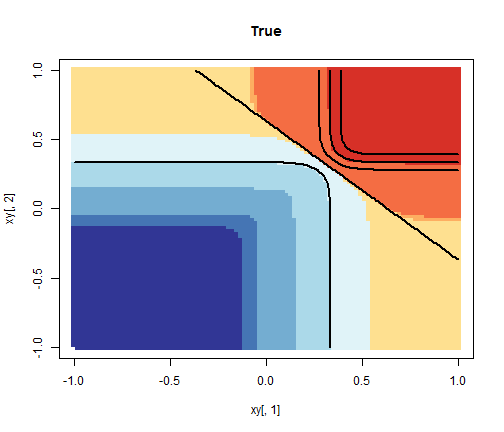

[figure not shown]

```r
truth <- (zeta1(xy[,1]) *zeta1(xy[,2]))
z1_cut <-cut(truth, quantile(truth,seq(0,1, length.out=k))+seq(0,0.001, length.out=k)   )
plot(xy[,1],xy[,2], col=my.cols[z1_cut], pch = 15, main="True")
contour(x,y,z1, drawlabels=FALSE, nlevels=k, lwd=2, add=TRUE)
```

##### With no treatment effect but selection on the observables (A)

```r
tau =0
p=3
X = matrix(runif(n * p, 0, 1), n, p) # features
propensity = (1 + dbeta(X[,3], 2, 4)) / 4
mu = 2*X[,3] - 1
D = rbinom(n, 1, propensity)
Y = mu + (D -0.5)* tau + rnorm(n)

tree_mult = 1000
X.test =matrix(runif(n*p), n, p)

forest = propensityForest(X, Y, D, num.trees = tree_mult, sample.size = n^(0.8), nodesize = 1)
```

```
## [1] "Building trees ..."
## [1] "Tree 1"
## [1] "Tree 2"
## [1] "Tree 3"
## [1] "Tree 4"
## [1] "Tree 5"
## [1] "Tree 6"
## [1] "Tree 7"
## [1] "Tree 8"
## [1] "Tree 9"
## [1] "Tree 10"
## [1] "Tree 11"
## [1] "Tree 12"
## [1] "Tree 13"
## [1] "Tree 14"
```

[output cut: 986 more lines]

```r
predictions = predict(forest, X.test)
forest.ci = randomForestInfJack(forest, X.test, calibrate = TRUE)
```